# Exploring the BRFSS data

## Setup

### Load packages

```r
library(ggplot2)
library(dplyr)
```

### Load data

```r
load("brfss2013.RData")
```

## Part 1: Data

For data collection both in-house interviewers and contracts with telephone callcenters are used. Random Digit Dialing used for sample randomization. Interview and calls are common cause of non-response bias. Method of calling might cause bias of availability - as not all citizens have home phones. Some false information we can conduct out is filtered out using weighting and stratification variables.

## Part 2: Research questions

**Research quesion 1:**

1. Is there any correlations between Physical Activity of person and Depression? As we have idea that higher physical activity is associated with lower level of depression and vise versa.

**Research quesion 2:**

**Research quesion 3:**

3. Do we have any interconnection of health days and sleep time? How does those variable correlate with general health of respondent?

## Part 3: Exploratory data analysis

**Research quesion 1:** X_totinda: Leisure Time phys activity addepev2: ever told you had a depressive disorder

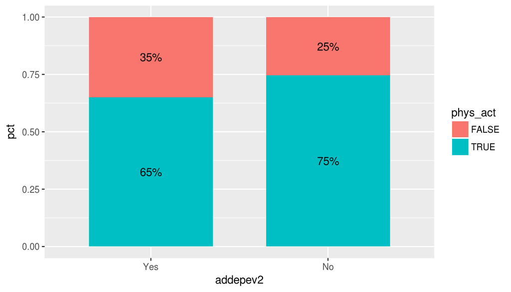

```r
brfss2013 <- brfss2013 %>% mutate(phys_act = ifelse( X_totinda == "Had physical activity or exercise", TRUE, FALSE));
# filter n/a of the data
sub_brfss <- dplyr::filter(brfss2013, !is.na(phys_act))
sub_brfss <- dplyr::filter(sub_brfss, !is.na(addepev2))
sub_brfss %>%
  count(phys_act, addepev2)%>%
  group_by(addepev2)%>%
  mutate(pct = n/sum(n))%>%
  ggplot(aes(x = addepev2, y = pct, fill = phys_act)) +
  geom_col(width=0.7) +
  geom_text(aes(label = paste0(round(pct*100), '%')),
            position=position_stack(vjust = 0.5))
```

Yes/no - indicates if you where diagnosed with depression, and bar - percentage of physical activity As we see there are more physicly active people in group of non-depression, and strong difference between those diagnosed with depression. We assume that there is some correlation between those variables

**Research quesion 2:**

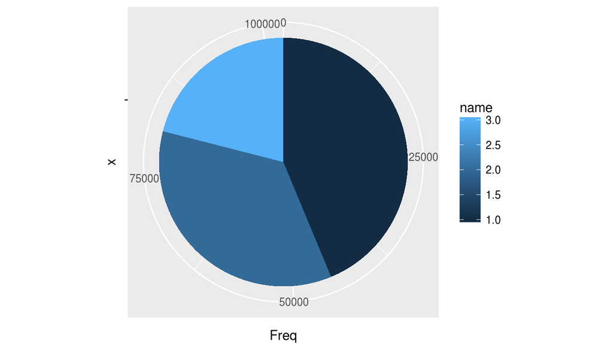

```r
#filter all rows which does not have information
fl_brfss <- brfss2013 %>% filter(!is.na(ssbsugar)) %>% filter(!is.na(ssbfrut2))
#examine distribution of oftennes sugar drinks
#ggplot(fl_brfss, aes(ssbsugar)) + geom_bar()
sugar_mean = mean(fl_brfss$ssbsugar)
#ggplot(fl_brfss, aes(ssbfrut2)) + geom_bar()
frut_mean = mean(fl_brfss$ssbfrut2)
#we assume that often for sugar drinks and sweetened fruit drinks is more than 200
#let's create variables which describe frequence of sugar and sweetened drinks usage
fl_brfss <- fl_brfss %>% mutate(freq_sugar = ifelse(ssbsugar > sugar_mean, TRUE, FALSE)) %>% mutate(freq_frut = ifelse(ssbfrut2 > frut_mean, TRUE, FALSE))
#create frequence table of 2 variables
df <- as.data.frame(table(fl_brfss$freq_frut, fl_brfss$freq_sugar))
#create variable of 2 factors
df <- df %>% mutate(name = as.numeric(Var1) + as.numeric(Var2) - 1)
ggplot(df, aes(x="", y=Freq, fill=name))+
geom_bar(width = 1, stat = "identity") + coord_polar("y", start=0)
```

**Research quesion 3:**

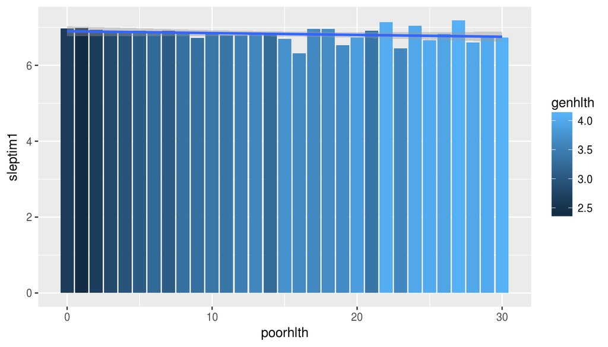

```r
#sleptim1 genhlth poorhlth
#read new dataset of unique healthy days poorhlth
poor_hlth <- brfss2013 %>% filter(!is.na(sleptim1)) %>% filter(!is.na(genhlth)) %>% filter(!is.na(poorhlth)) %>% select(c(sleptim1, genhlth, poorhlth)) %>% mutate(genhlth=as.numeric(genhlth))
poor_hlth <- aggregate(poor_hlth, list(Days = poor_hlth$poorhlth), mean)
ggplot(poor_hlth, aes(y = sleptim1, x = poorhlth, fill = genhlth)) + geom_bar(stat="identity") + geom_smooth(method = "lm")
```

Poorhlth - number of days in month when respondent feeling bad, sleptim1 - hours of sleep he have on average and genlth - how assess his own health. As we see, genhlth strongly correlates with poorhlth - more days on month respondend feels bad - worsen he feels in general. There is trend of sleep time and poor health - less sleep time - more bad health days respondent have.